# **Analysis of Wine Quality**

Muhammad Osama

## **Data Set Description**

This data set has two types of wines and their various attributes. The quality of wine is the target variable in the data set. There are 12 predictors in the data set. The data set has a total of 6497 rows. There were no null values found in the data set.

|  | Type | fixed.acidity | volatile.acidity | citric.acid | residual.sugar | chlorides | free.sulfur.dioxide | total.sulfur.dioxide | density | pH | sulphates | alcohol | quality |
| --- | --- | --- | --- | --- | --- | --- | --- | --- | --- | --- | --- | --- | --- |
| 1 | 0 | 7.4 | 0.7 | 0 | 1.9 | 0.076 | 11 | 34 | 0.9978 | 3.51 | 0.56 | 9.4 | 5 |
| 2 | 0 | 7.8 | 0.88 | 0 | 2.6 | 0.098 | 25 | 67 | 0.9968 | 3.2 | 0.68 | 9.8 | 5 |
| 3 | 0 | 7.8 | 0.76 | 0.04 | 2.3 | 0.092 | 15 | 54 | 0.997 | 3.26 | 0.65 | 9.8 | 5 |
| 4 | 0 | 11.2 | 0.28 | 0.56 | 1.9 | 0.075 | 17 | 60 | 0.998 | 3.16 | 0.58 | 9.8 | 6 |
| 5 | 0 | 7.4 | 0.7 | 0 | 1.9 | 0.076 | 11 | 34 | 0.9978 | 3.51 | 0.56 | 9.4 | 5 |
| 6 | 0 | 7.4 | 0.66 | 0 | 1.8 | 0.075 | 13 | 40 | 0.9978 | 3.51 | 0.56 | 9.4 | 5 |
| 7 | 0 | 7.9 | 0.6 | 0.06 | 1.6 | 0.069 | 15 | 59 | 0.9964 | 3.3 | 0.46 | 9.4 | 5 |
| 8 | 0 | 7.3 | 0.65 | 0 | 1.2 | 0.065 | 15 | 21 | 0.9946 | 3.39 | 0.47 | 10 | 7 |
| 9 | 0 | 7.8 | 0.58 | 0.02 | 2 | 0.073 | 9 | 18 | 0.9968 | 3.36 | 0.57 | 9.5 | 7 |
| 10 | 0 | 7.5 | 0.5 | 0.36 | 6.1 | 0.071 | 17 | 102 | 0.9978 | 3.35 | 0.8 | 10.5 | 5 |

[output cut: 6487 more lines]

### **Summary of Data Set**

```
      Type        fixed.acidity    volatile.acidity  citric.acid
 Min.   :0.0000   Min.   : 3.800   Min.   :0.0800   Min.   :0.0000
 1st Qu.:1.0000   1st Qu.: 6.400   1st Qu.:0.2300   1st Qu.:0.2500
 Median :1.0000   Median : 7.000   Median :0.2900   Median :0.3100
 Mean   :0.7539   Mean   : 7.215   Mean   :0.3397   Mean   :0.3186
 3rd Qu.:1.0000   3rd Qu.: 7.700   3rd Qu.:0.4000   3rd Qu.:0.3900
 Max.   :1.0000   Max.   :15.900   Max.   :1.5800   Max.   :1.6600
 residual.sugar     chlorides       free.sulfur.dioxide total.sulfur.dioxide
 Min.   : 0.600   Min.   :0.00900   Min.   :  1.00      Min.   :  6.0
 1st Qu.: 1.800   1st Qu.:0.03800   1st Qu.: 17.00      1st Qu.: 77.0
 Median : 3.000   Median :0.04700   Median : 29.00      Median :118.0
 Mean   : 5.443   Mean   :0.05603   Mean   : 30.53      Mean   :115.7
 3rd Qu.: 8.100   3rd Qu.:0.06500   3rd Qu.: 41.00      3rd Qu.:156.0
 Max.   :65.800   Max.   :0.61100   Max.   :289.00      Max.   :440.0
    density             pH          sulphates         alcohol
 Min.   :0.9871   Min.   :2.720   Min.   :0.2200   Min.   : 8.00
 1st Qu.:0.9923   1st Qu.:3.110   1st Qu.:0.4300   1st Qu.: 9.50
 Median :0.9949   Median :3.210   Median :0.5100   Median :10.30
 Mean   :0.9947   Mean   :3.219   Mean   :0.5313   Mean   :10.49
 3rd Qu.:0.9970   3rd Qu.:3.320   3rd Qu.:0.6000   3rd Qu.:11.30
 Max.   :1.0390   Max.   :4.010   Max.   :2.0000   Max.   :14.90
    quality
 Min.   :3.000
 1st Qu.:5.000
 Median :6.000
 Mean   :5.818
 3rd Qu.:6.000
 Max.   :9.000
```

## **Data Set Distribution**

The following plot shows the distribution of each variable and the correlation between all the variables of the data set including their significance levels:

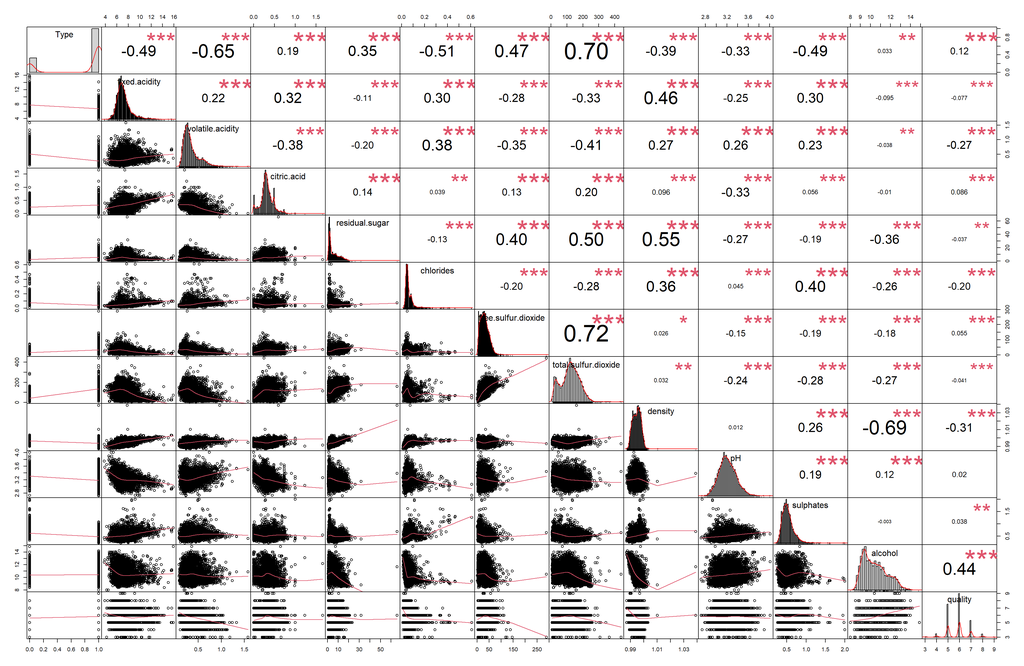

## **Linear Regression using Bootstrap**

Performed bootstrap sampling on the data set to create the training set. All those tuples not present in the training set were used as the testing set. The results are as follows:

```
 "Bootstrap Linear Regression Mean Squared Error: 0.540498036141454"
```

## **Linear Regression using Holdout Method**

Performed Linear Regression on the data set using the hold out method. The data set was split into training ans test set in the ratio 66% to 34% respectively. Linear Regression model was fit on the training set and used to predict the test set. The results are as follows:

### **Linear Regression Model Summary**

```
Call:
lm(formula = quality ~ ., data = train_1)

Residuals:
    Min      1Q  Median      3Q     Max
-3.7800 -0.4717 -0.0501  0.4667  3.0118

Coefficients:
                       Estimate Std. Error t value Pr(>|t|)
(Intercept)           1.136e+02  1.911e+01   5.946 2.96e-09 ***
Type                 -3.542e-01  7.316e-02  -4.842 1.33e-06 ***
fixed.acidity         9.674e-02  2.057e-02   4.703 2.64e-06 ***
volatile.acidity     -1.390e+00  1.022e-01 -13.606  < 2e-16 ***
citric.acid          -9.175e-02  9.780e-02  -0.938  0.34823
residual.sugar        6.546e-02  7.682e-03   8.521  < 2e-16 ***
chlorides            -9.720e-01  4.080e-01  -2.382  0.01724 *
free.sulfur.dioxide   4.703e-03  9.377e-04   5.015 5.52e-07 ***
total.sulfur.dioxide -1.195e-03  4.017e-04  -2.976  0.00294 **
density              -1.130e+02  1.936e+01  -5.836 5.74e-09 ***
pH                    5.250e-01  1.157e-01   4.538 5.83e-06 ***
sulphates             7.334e-01  9.585e-02   7.651 2.45e-14 ***
alcohol               2.168e-01  2.431e-02   8.920  < 2e-16 ***
---
Signif. codes:  0 '***' 0.001 '**' 0.01 '*' 0.05 '.' 0.1 ' ' 1

Residual standard error: 0.7375 on 4276 degrees of freedom
Multiple R-squared:  0.294, Adjusted R-squared:  0.292
F-statistic: 148.4 on 12 and 4276 DF,  p-value: < 2.2e-16
```

### **Linear Regression Model Error Rates**

```
 "Holdout Linear Regression Mean Squared Error: 0.526157763718567"
```

```
 "Holdout Linear Regression Mean Absolute Deviation: 0.563668055820335"
```

## **Linear Model Assumptions**

Checked if the linear model assumptions were met in the hold out model. The results are as follows:

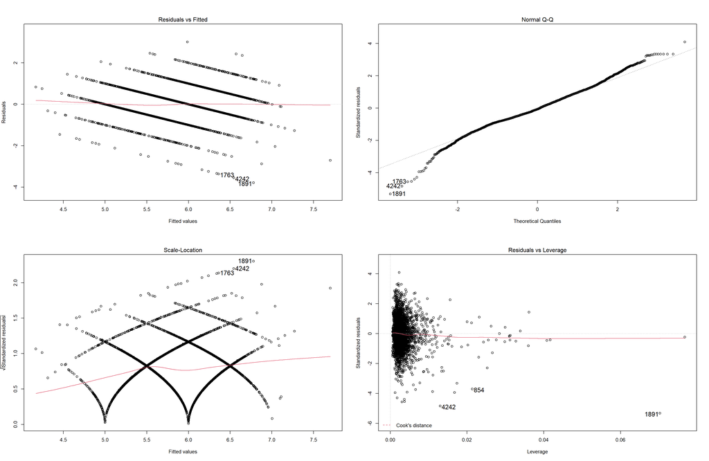

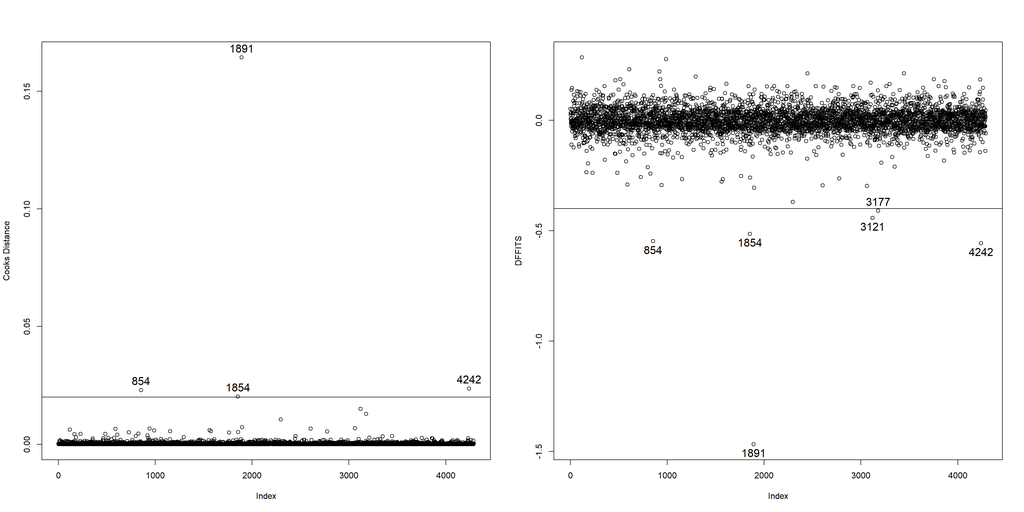

Analysis of the Cook’s distance & DFFITS plot revealed some potential influential points which were 854, 1854, 1891, 3121, 3177, 4242. I examined the effect of each of these points by removing them and then rerunning the model without them. The results are as follows:

### **Outlier Check**

```
    Welch Two Sample t-test

data:  mse_model_base and mse_model_outlier_1
t = 1.7144, df = 1996.7, p-value = 0.08661
alternative hypothesis: true difference in means is not equal to 0
95 percent confidence interval:
 -0.0002208236  0.0032893859
sample estimates:
mean of x mean of y
0.5478279 0.5462936
```

```
    Welch Two Sample t-test

data:  mse_model_base and mse_model_outlier_2
t = 0.30058, df = 1997.8, p-value = 0.7638
alternative hypothesis: true difference in means is not equal to 0
95 percent confidence interval:
 -0.001474463  0.002008245
sample estimates:
mean of x mean of y
0.5478279 0.5475610
```

```
    Welch Two Sample t-test

data:  mse_model_base and mse_model_outlier_3
t = 3.0365, df = 1998, p-value = 0.002424
alternative hypothesis: true difference in means is not equal to 0
95 percent confidence interval:
 0.000948486 0.004407985
sample estimates:
mean of x mean of y
0.5478279 0.5451496
```

```
    Welch Two Sample t-test

data:  mse_model_base and mse_model_outlier_4
t = 0.2619, df = 1997.6, p-value = 0.7934
alternative hypothesis: true difference in means is not equal to 0
95 percent confidence interval:
 -0.001489873  0.001949140
sample estimates:
mean of x mean of y
0.5478279 0.5475982
```

```
    Welch Two Sample t-test

data:  mse_model_base and mse_model_outlier_5
t = 0.92809, df = 1997.2, p-value = 0.3535
alternative hypothesis: true difference in means is not equal to 0
95 percent confidence interval:
 -0.000903401  0.002526613
sample estimates:
mean of x mean of y
0.5478279 0.5470163
```

```
    Welch Two Sample t-test

data:  mse_model_base and mse_model_outlier_6
t = 3.0587, df = 1997.1, p-value = 0.002253
alternative hypothesis: true difference in means is not equal to 0
95 percent confidence interval:
 0.0009594361 0.0043882707
sample estimates:
mean of x mean of y
0.5478279 0.5451540
```

Looking at the results from the t tests, we can see that tuples with index 1891 & 4242 are influential outliers at the 95% confidence interval.

## **Cross Validation**

```
 "Cross Validation Estimate of Prediction Error: 0.538620834703751"
```

## **Backward Feature Selection**

Performed backward feature selection using AIC score on the hold out model. The results for the feature selection are as follows:

### **Backward Selection Results**

```
Start:  AIC=-2599.31
quality ~ Type + fixed.acidity + volatile.acidity + citric.acid +
    residual.sugar + chlorides + free.sulfur.dioxide + total.sulfur.dioxide +
    density + pH + sulphates + alcohol

                       Df Sum of Sq    RSS     AIC
- citric.acid           1     0.479 2326.0 -2600.4
<none>                              2325.5 -2599.3
- chlorides             1     3.087 2328.6 -2595.6
- total.sulfur.dioxide  1     4.816 2330.3 -2592.4
- pH                    1    11.202 2336.7 -2580.7
- fixed.acidity         1    12.032 2337.6 -2579.2
- Type                  1    12.750 2338.3 -2577.9
- free.sulfur.dioxide   1    13.678 2339.2 -2576.2
- density               1    18.525 2344.1 -2567.3
- sulphates             1    31.837 2357.4 -2543.0
- residual.sugar        1    39.491 2365.0 -2529.1
- alcohol               1    43.272 2368.8 -2522.2
- volatile.acidity      1   100.684 2426.2 -2419.5

Step:  AIC=-2600.43
quality ~ Type + fixed.acidity + volatile.acidity + residual.sugar +
    chlorides + free.sulfur.dioxide + total.sulfur.dioxide +
    density + pH + sulphates + alcohol

                       Df Sum of Sq    RSS     AIC
<none>                              2326.0 -2600.4
- chlorides             1     3.592 2329.6 -2595.8
- total.sulfur.dioxide  1     5.174 2331.2 -2592.9
- fixed.acidity         1    11.553 2337.6 -2581.2
- pH                    1    11.584 2337.6 -2581.1
- Type                  1    13.224 2339.2 -2578.1
- free.sulfur.dioxide   1    13.772 2339.8 -2577.1
- density               1    18.865 2344.9 -2567.8
- sulphates             1    31.606 2357.6 -2544.5
- residual.sugar        1    39.703 2365.7 -2529.8
- alcohol               1    42.794 2368.8 -2524.2
- volatile.acidity      1   108.759 2434.8 -2406.4
```

### **Backward Selected Model Error Rates**

```
 "Linear Regression (Backward Selected Model) Mean Squared Error: 0.526060763876279"
```

```
 "Linear Regression (Backward Selected Model) Mean Absolute Deviation: 0.563635264950485"
```

### **Summary of Backward Selected Model**

```
Call:
lm(formula = quality ~ Type + fixed.acidity + volatile.acidity +
    residual.sugar + chlorides + free.sulfur.dioxide + total.sulfur.dioxide +
    density + pH + sulphates + alcohol, data = train_1)

Residuals:
    Min      1Q  Median      3Q     Max
-3.7689 -0.4711 -0.0499  0.4653  3.0108

Coefficients:
                       Estimate Std. Error t value Pr(>|t|)
(Intercept)           1.145e+02  1.908e+01   6.001 2.13e-09 ***
Type                 -3.596e-01  7.293e-02  -4.931 8.48e-07 ***
fixed.acidity         9.279e-02  2.013e-02   4.609 4.16e-06 ***
volatile.acidity     -1.357e+00  9.597e-02 -14.142  < 2e-16 ***
residual.sugar        6.562e-02  7.680e-03   8.544  < 2e-16 ***
chlorides            -1.034e+00  4.025e-01  -2.570  0.01020 *
free.sulfur.dioxide   4.718e-03  9.376e-04   5.032 5.05e-07 ***
total.sulfur.dioxide -1.233e-03  3.997e-04  -3.084  0.00205 **
density              -1.139e+02  1.934e+01  -5.890 4.17e-09 ***
pH                    5.326e-01  1.154e-01   4.615 4.04e-06 ***
sulphates             7.302e-01  9.579e-02   7.623 3.02e-14 ***
alcohol               2.144e-01  2.416e-02   8.871  < 2e-16 ***
---
Signif. codes:  0 '***' 0.001 '**' 0.01 '*' 0.05 '.' 0.1 ' ' 1

Residual standard error: 0.7375 on 4277 degrees of freedom
Multiple R-squared:  0.2939,    Adjusted R-squared:  0.2921
F-statistic: 161.8 on 11 and 4277 DF,  p-value: < 2.2e-16
```

### **ANOVA Base Model & Backward Selected Model**

```
Analysis of Variance Table

Model 1: quality ~ Type + fixed.acidity + volatile.acidity + residual.sugar +
    chlorides + free.sulfur.dioxide + total.sulfur.dioxide +
    density + pH + sulphates + alcohol
Model 2: quality ~ Type + fixed.acidity + volatile.acidity + citric.acid +
    residual.sugar + chlorides + free.sulfur.dioxide + total.sulfur.dioxide +
    density + pH + sulphates + alcohol
  Res.Df    RSS Df Sum of Sq      F Pr(>F)
1   4277 2326.0
2   4276 2325.5  1   0.47864 0.8801 0.3482
```

## **Ridge Regression Model**

Performed ridge regression on the hold out training set. The results are as follows:

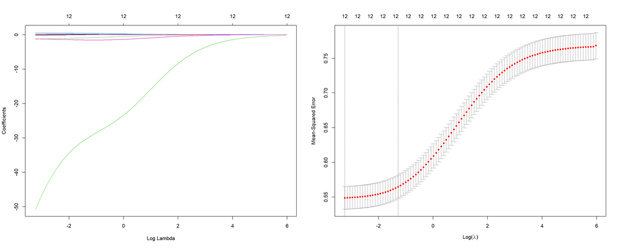

### **Ridge Regression Minimum Lambda & Coefficients**

```
 "Minimum value of lambda for Ridge Regression: 0.0393389261772647"
```

```
13 x 1 sparse Matrix of class "dgCMatrix"
                                s1
(Intercept)           52.459912733
Type                  -0.170354775
fixed.acidity          0.040744330
volatile.acidity      -1.274680779
citric.acid           -0.040321002
residual.sugar         0.038240180
chlorides             -1.228630622
free.sulfur.dioxide    0.004694996
total.sulfur.dioxide  -0.001388768
density              -50.764395568
pH                     0.272170513
sulphates              0.648273717
alcohol                0.265701313
```

```
 "Ridge Regression Mean Squared Error: 0.528554301927321"
```

```
 "Ridge Regression Mean Absolute Deviation: 0.565029916320992"
```

## **LASSO Regression Model**

Performed LASSO regression on the hold out training set. The results are as follows:

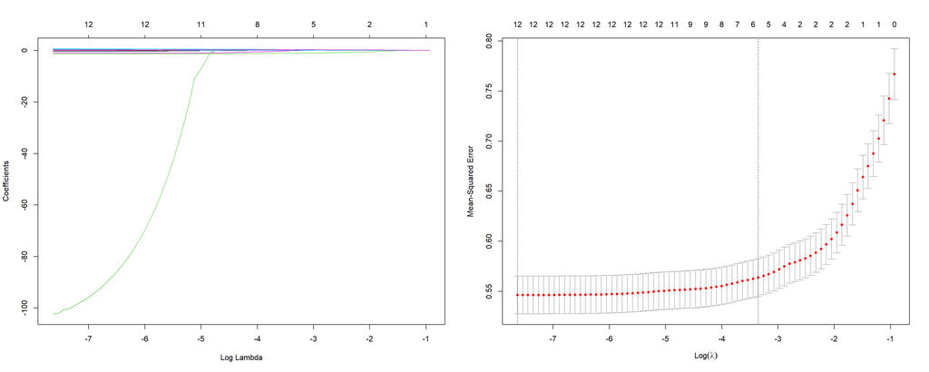

### **LASSO Regression Minimum Lambda & Coefficients**

```
 "Minimum value of lambda for LASSO regression: 0.000484988668707929"
```

```
13 x 1 sparse Matrix of class "dgCMatrix"
                                s1
(Intercept)           1.030867e+02
Type                 -3.276800e-01
fixed.acidity         8.683147e-02
volatile.acidity     -1.384337e+00
citric.acid          -8.573408e-02
residual.sugar        6.125756e-02
chlorides            -9.776873e-01
free.sulfur.dioxide   4.689429e-03
total.sulfur.dioxide -1.217415e-03
density              -1.022981e+02
pH                    4.805965e-01
sulphates             7.184658e-01
alcohol               2.279554e-01
```

### **LASSO Regression Error Rates**

```
 "LASSO Regression Mean Squared Error: 0.526071145510482"
```

```
 "LASSO Regression Mean Absolute Deviation: 0.563697263958701"
```

## **ANOVA**

I am investigating if the differences in percentage volume of alcohol in wine is due to the different types of wine. I used one way ANOVA to perform this analysis. The results are as follows:

### **One Way Anova (Type of Wine)**

```
                       Df Sum Sq Mean Sq F value  Pr(>F)
as_factor(df_2$Type)    1     10  10.045   7.068 0.00787 **
Residuals            6495   9231   1.421
---
Signif. codes:  0 '***' 0.001 '**' 0.01 '*' 0.05 '.' 0.1 ' ' 1
```

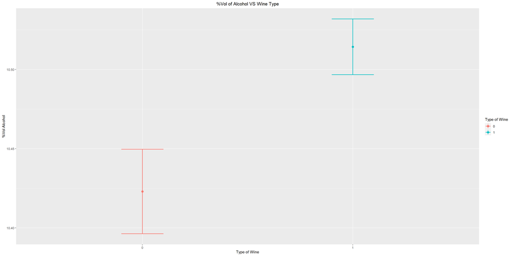

## **ANOVA with continuous co variate**

I am investigating the effect of a co variate which is fixed acidity to check if the differences in percentage volume of alcohol due to the type of wine are still significant. The results are as follows:

### **One Way ANOVA (Type & Fixed Acidity)**

```
Anova Table (Type III tests)

Response: df_2$alcohol
                      Sum Sq   Df   F value    Pr(>F)
(Intercept)          14090.7    1 9995.5525 < 2.2e-16 ***
as_factor(df_2$Type)     2.2    1    1.5634    0.2112
df_2$fixed.acidity      76.4    1   54.1631 2.073e-13 ***
Residuals             9154.6 6494
---
Signif. codes:  0 '***' 0.001 '**' 0.01 '*' 0.05 '.' 0.1 ' ' 1
```

### **Effect of Type of Wine with Fixed Acidity as Co Variate**

```
$emmeans
 Type emmean      SE   df lower.CL upper.CL
    0  10.53 0.03298 6494    10.46    10.59
    1  10.48 0.01760 6494    10.45    10.51

Confidence level used: 0.95

$contrasts
 contrast estimate     SE   df t.ratio p.value
 0 - 1      0.0489 0.0391 6494   1.250  0.2112
```

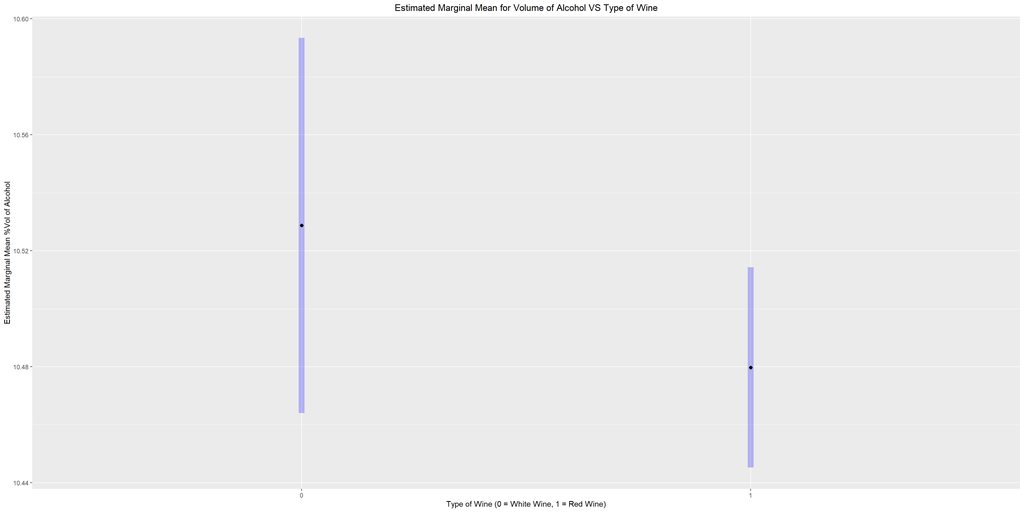

## **Two Way ANOVA (Type of Wine & Residual Sugar)**

I am investigating the affect of levels of residual sugar together with type of wine on percentage volume of alcohol. First, we will check if the interaction between levels of residual sugar and type of wine are significant. The results are as follows:

### **Interaction Check**

```
Analysis of Variance Table

Response: df_3$alcohol
                                                      Df Sum Sq Mean Sq
as_factor(df_3$Type)                                   1   10.0   10.04
as_factor(df_3$residual.sugar)                         2 1474.0  736.99
as_factor(df_3$Type):as_factor(df_3$residual.sugar)    2   36.4   18.18
Residuals                                           6491 7720.6    1.19
                                                     F value    Pr(>F)
as_factor(df_3$Type)                                  8.4451  0.003673 **
as_factor(df_3$residual.sugar)                      619.6192 < 2.2e-16 ***
as_factor(df_3$Type):as_factor(df_3$residual.sugar)  15.2860 2.382e-07 ***
Residuals
---
Signif. codes:  0 '***' 0.001 '**' 0.01 '*' 0.05 '.' 0.1 ' ' 1
```

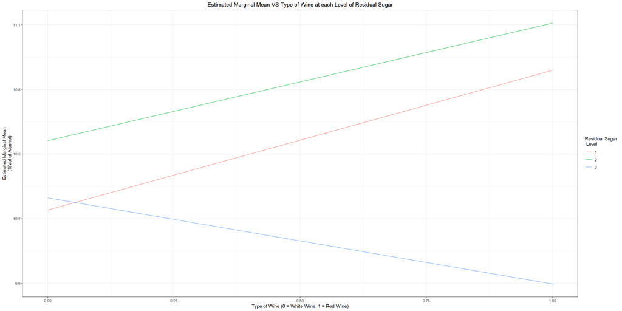

We can see from the results and the plot that there is an interaction between the type of wine and the levels of residual sugar. Hence, we will now look at the simple effects of the type of wine and the levels of residual sugar on percentage volume of alcohol.

### **Simple Effects of Type of Wine**

```
$emmeans
residual.sugar = 1:
 Type emmean      SE   df lower.CL upper.CL
    0 10.241 0.04232 6491   10.158   10.324
    1 10.890 0.02815 6491   10.834   10.945

residual.sugar = 2:
 Type emmean      SE   df lower.CL upper.CL
    0 10.562 0.03637 6491   10.491   10.634
    1 11.108 0.03065 6491   11.048   11.168

residual.sugar = 3:
 Type emmean      SE   df lower.CL upper.CL
    0 10.297 0.18177 6491    9.941   10.654
    1  9.897 0.02363 6491    9.851    9.943

Confidence level used: 0.95

$contrasts
residual.sugar = 1:
 contrast estimate     SE   df t.ratio p.value
 0 - 1      -0.649 0.0508 6491 -12.761  <.0001

residual.sugar = 2:
 contrast estimate     SE   df t.ratio p.value
 0 - 1      -0.546 0.0476 6491 -11.476  <.0001

residual.sugar = 3:
 contrast estimate     SE   df t.ratio p.value
 0 - 1       0.400 0.1833 6491   2.184  0.0290
```

### **Simple Effects of Residual Sugar**

```
$emmeans
Type = 0:
 residual.sugar emmean      SE   df lower.CL upper.CL
              1 10.241 0.04232 6491   10.158   10.324
              2 10.562 0.03637 6491   10.491   10.634
              3 10.297 0.18177 6491    9.941   10.654

Type = 1:
 residual.sugar emmean      SE   df lower.CL upper.CL
              1 10.890 0.02815 6491   10.834   10.945
              2 11.108 0.03065 6491   11.048   11.168
              3  9.897 0.02363 6491    9.851    9.943

Confidence level used: 0.95

$contrasts
Type = 0:
 contrast estimate     SE   df t.ratio p.value
 1 - 2     -0.3216 0.0558 6491  -5.762  <.0001
 1 - 3     -0.0563 0.1866 6491  -0.302  0.9511
 2 - 3      0.2653 0.1854 6491   1.431  0.3249

Type = 1:
 contrast estimate     SE   df t.ratio p.value
 1 - 2     -0.2188 0.0416 6491  -5.259  <.0001
 1 - 3      0.9926 0.0368 6491  27.008  <.0001
 2 - 3      1.2114 0.0387 6491  31.303  <.0001

P value adjustment: tukey method for comparing a family of 3 estimates
```

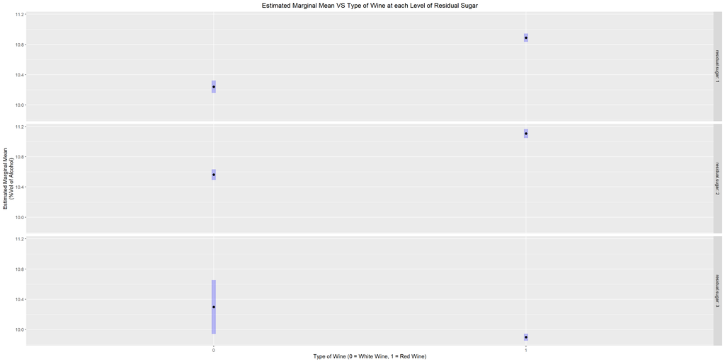

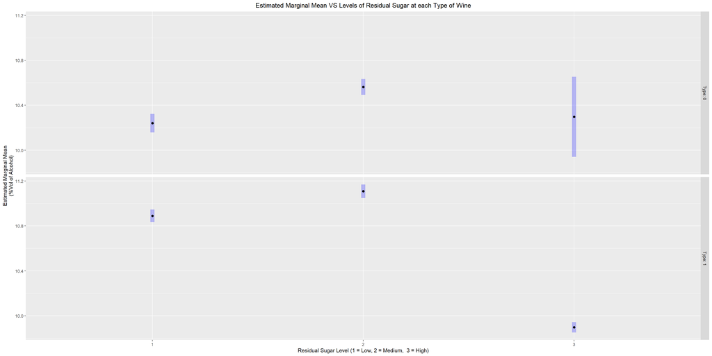

## **Two Way ANOVA (Type of Wine & pH)**

I am investigating the affect of levels of pH together with type of wine on percentage volume of alcohol. First, we will check if the interaction between levels of pH and type of wine are significant. The results are as follows:

### **Interaction Check**

```
Call:
lm(formula = df_3$alcohol ~ df_3$Type + df_3$pH + (df_3$Type *
    df_3$pH))

Residuals:
    Min      1Q  Median      3Q     Max
-2.7013 -0.9789 -0.2013  0.7987  4.7268

Coefficients:
                  Estimate Std. Error t value Pr(>|t|)
(Intercept)        9.83849    0.12222  80.497  < 2e-16 ***
df_3$Type          0.21806    0.13261   1.644    0.100
df_3$pH            0.33474    0.06792   4.929 8.49e-07 ***
df_3$Type:df_3$pH -0.01236    0.07605  -0.162    0.871
---
Signif. codes:  0 '***' 0.001 '**' 0.01 '*' 0.05 '.' 0.1 ' ' 1

Residual standard error: 1.182 on 6493 degrees of freedom
Multiple R-squared:  0.01818,   Adjusted R-squared:  0.01772
F-statistic: 40.07 on 3 and 6493 DF,  p-value: < 2.2e-16
```

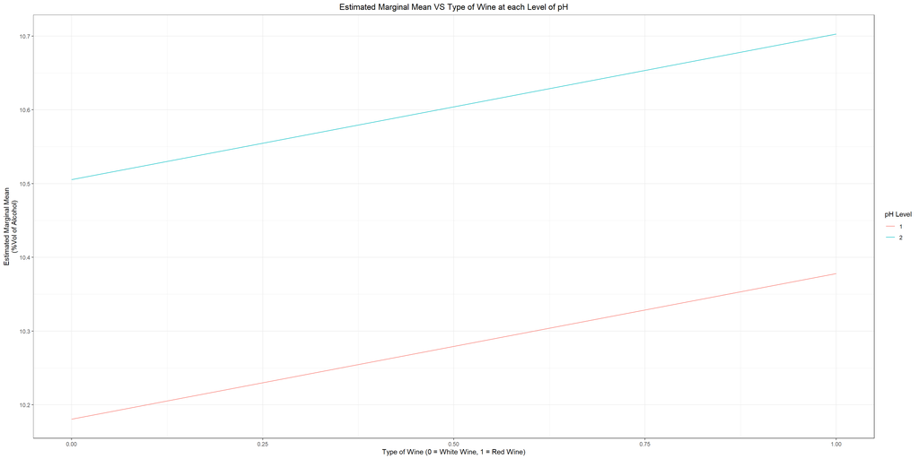

We can see from the results and the plot that there is no interaction between the type of wine and the levels of pH. Hence, we will now look at the main effects of the type of wine and the levels of pH on the percentage volume of alcohol.

### **Two Way ANOVA (Type of Wine & pH) without interaction**

```
Anova Table (Type III tests)

Response: df_3$alcohol
                     Sum Sq   Df   F value    Pr(>F)
(Intercept)          103903    1 74368.126 < 2.2e-16 ***
as_factor(df_3$Type)     43    1    30.934 2.776e-08 ***
as_factor(df_3$pH)      158    1   113.013 < 2.2e-16 ***
Residuals              9073 6494
---
Signif. codes:  0 '***' 0.001 '**' 0.01 '*' 0.05 '.' 0.1 ' ' 1
```

### **Main Effect of pH**

```
$emmeans
 pH emmean      SE   df lower.CL upper.CL
  1  10.28 0.02464 6494    10.23    10.33
  2  10.60 0.02127 6494    10.56    10.65

Results are averaged over the levels of: Type
Confidence level used: 0.95

$contrasts
 contrast estimate     SE   df t.ratio p.value
 1 - 2      -0.325 0.0306 6494 -10.631  <.0001

Results are averaged over the levels of: Type
```

### **Main Effect of Type of Wine**

```
$emmeans
 Type emmean      SE   df lower.CL upper.CL
    0  10.34 0.03050 6494    10.28    10.40
    1  10.54 0.01707 6494    10.51    10.57

Results are averaged over the levels of: pH
Confidence level used: 0.95

$contrasts
 contrast estimate     SE   df t.ratio p.value
 0 - 1      -0.197 0.0355 6494  -5.562  <.0001

Results are averaged over the levels of: pH
```

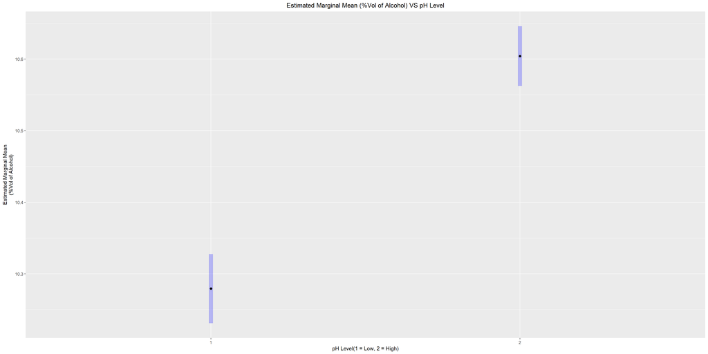

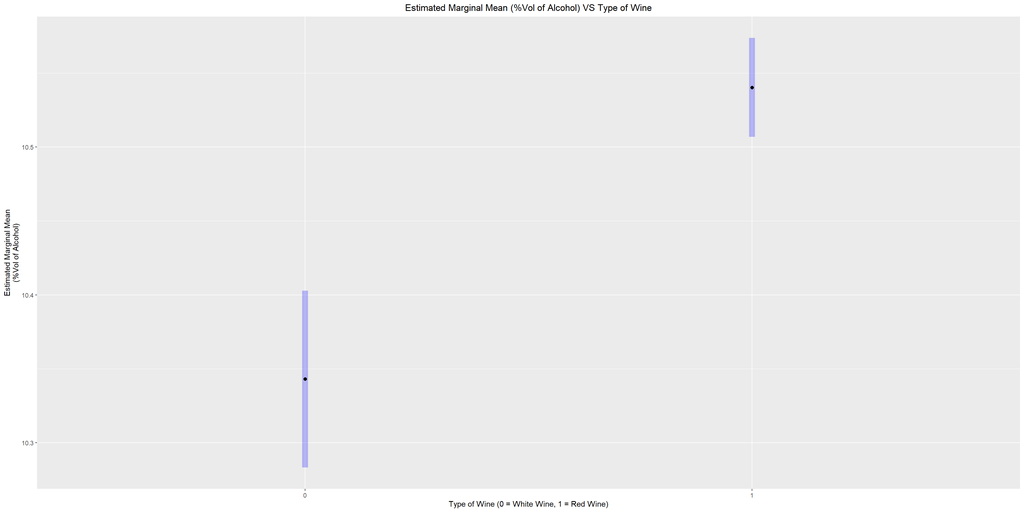

We can see from the ANOVA test and the plots that both the type of wine and level of pH are together significant in determining the change in the percentage volume of alcohol. The plots show that there is a significant difference in the percentage volume of alcohol in each type of wine when averaged over all the levels of pH. The plots also show that there is a significant difference in the percentage volume of alcohol at each pH level when averaged over all the types of wine.

## **Polynomial Regression**

I am looking at different polynomial regression models and investigating which one is the best for modelling the data. The results are as follows:

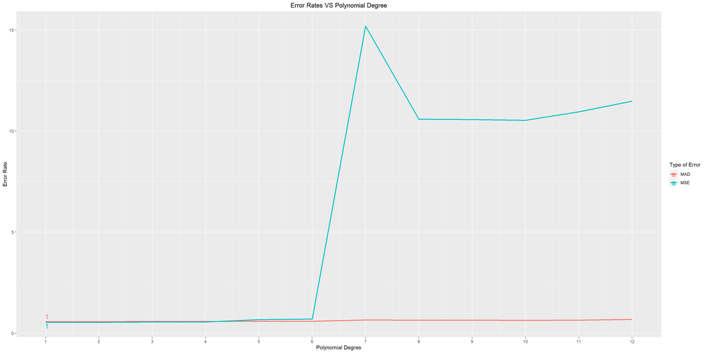

### **Degree 1 Linear Model Error Rate on Validation Data Set**

We can see from the above plots based on the error rates that the model of polynomial regression of degree 1 is the best model as it has the lowest error rate. Now we will check the error rate of the polynomial degree 1 model on the validation data set. The results are as follows:

```
 "Logistic Regression Mean Squared Error: 0.562301433803686"
```

```
 "Logistic Regression Mean Absolute Deviation: 0.578237166948388"
```

## **Logistic Regression**

I performed logistic regression on the data set by converting the target variable to a nominal attribute having values 0 and 1. 0 corresponds to quality less than or equal to 5 and 1 corresponds to quality greater than 5. The results are as follows:

### **Summary of Logistic Regression Model**

```
Call:
glm(formula = quality ~ ., family = "binomial", data = logistic_train)

Deviance Residuals:
    Min       1Q   Median       3Q      Max
-3.3966  -0.9196   0.4152   0.8750   2.4451

Coefficients:
                       Estimate Std. Error z value Pr(>|z|)
(Intercept)           1.016e+02  5.422e+01   1.874 0.060994 .
Type                  1.226e-01  2.060e-01   0.595 0.551713
fixed.acidity         2.004e-01  6.061e-02   3.307 0.000944 ***
volatile.acidity     -3.880e+00  3.177e-01 -12.213  < 2e-16 ***
citric.acid          -9.375e-01  2.997e-01  -3.128 0.001759 **
residual.sugar        7.534e-02  2.275e-02   3.312 0.000926 ***
chlorides            -2.359e+00  1.044e+00  -2.259 0.023888 *
free.sulfur.dioxide   1.795e-02  3.500e-03   5.129 2.91e-07 ***
total.sulfur.dioxide -5.298e-03  1.308e-03  -4.052 5.09e-05 ***
density              -1.147e+02  5.508e+01  -2.082 0.037312 *
pH                    1.158e+00  3.755e-01   3.083 0.002049 **
sulphates             2.826e+00  3.052e-01   9.258  < 2e-16 ***
alcohol               7.549e-01  7.108e-02  10.620  < 2e-16 ***
---
Signif. codes:  0 '***' 0.001 '**' 0.01 '*' 0.05 '.' 0.1 ' ' 1

(Dispersion parameter for binomial family taken to be 1)

    Null deviance: 5850.3  on 4288  degrees of freedom
Residual deviance: 4650.0  on 4276  degrees of freedom
AIC: 4676

Number of Fisher Scoring iterations: 4
```

### **Logistic Regression Model Accuracy**

```
 "Logistic Regression Accuracy: 0.713315217391304"
```

### **Checking significance of model**

Null Hypothesis: All coefficients are equal to zero.  
Alternate Hypothesis: At least one of the coefficients is not zero.

```
Wald test:
----------

Chi-squared test:
X2 = 825.0, df = 12, P(> X2) = 0.0
```

From the results of the Wald chi-squared test, we can see that the chi-squared value is very high and the p-value is very small (< 0.05) which means that we reject the null hypothesis and conclude that logistic model is significant.

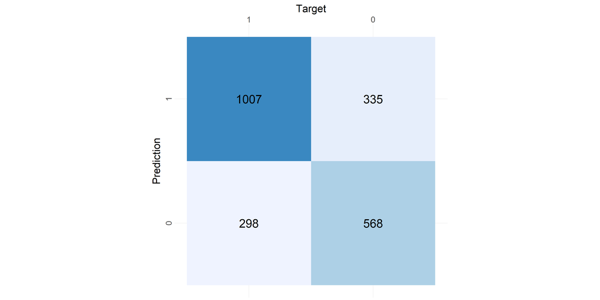

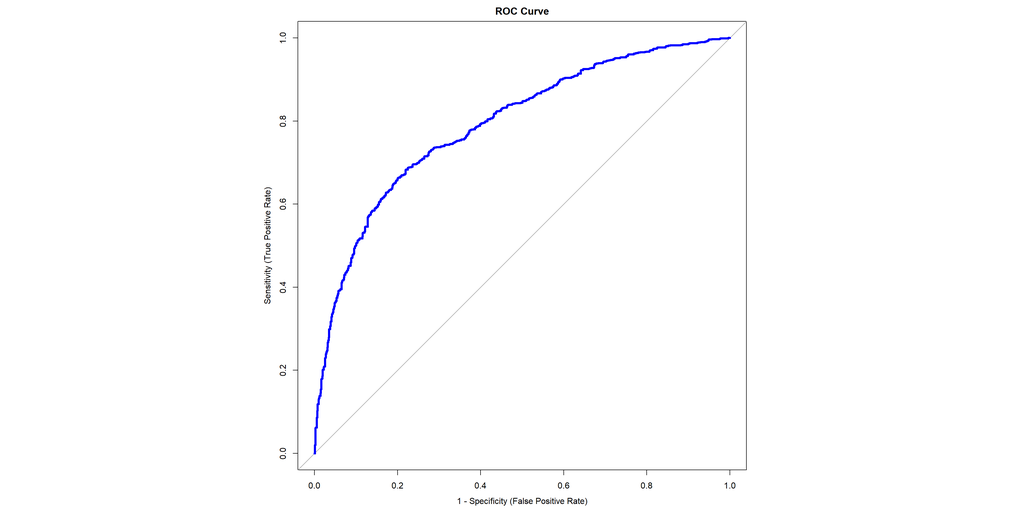

### **ROC area under curve**

```
Area under the curve: 0.7918
```

The area under curve for the model is very good and is greater than 0.5.

## **Proportion Test for Good Quality Wine**

I am investigating if the the proportion of good quality wine is the same for red and white wine types.

Null Hypothesis: The proportions are equal.  
Alternate Hypothesis: The proportions are not equal.

```
    2-sample test for equality of proportions without continuity
    correction

data:  c(855, 3258) out of c(1599, 4898)
X-squared = 88.323, df = 1, p-value < 2.2e-16
alternative hypothesis: two.sided
95 percent confidence interval:
 -0.1582521 -0.1026684
sample estimates:
   prop 1    prop 2
0.5347092 0.6651695
```

From the results, we can see that the p-value is very small (< 0.05) which means that we reject the null hypothesis and conclude that the proportion of good quality wine is different for both the wine types.